# 全球城市中心的医疗记录 探索性可视化

TidyTuesday · 2026-09-29 (Week 39)

作者

zlZayn

发布于

2026年10月1日

# 记录，不是设施

54.6% 的城市中心有医院记录，有药房记录的只有 **21.0%**

11,422 个城市中心里，有 5,037 个（44.1%）**两个字段都是空的**。所以本周的主线不是「哪里缺医院」，而是**这份数据库到底记了谁**——先把记录口径画清楚，再谈密度。

## 一、医院记录差 2.4 倍，药房记录差 14 倍

> raw 11422 -> plotted 11413 (9 个中心没有 World Bank 收入组)

[figure not shown]

图 1: Hospital records reach 88 percent of high-income centres but 36 percent of low-income ones; pharmacy records never exceed 64 percent.

**读数**：高收入组 88.4% 有医院记录、64.4% 有药房记录，两个数字的落差是 24.0 个百分点；低收入组是 36.5% / 4.5%，落差 32.0 个百分点。**药房字段的缺口处处大于医院字段，而且在低收入组近乎归零**——1050 个低收入中心里只有 47 个带药房记录，而这 47 个**全部同时带医院记录**（只有药房、没有医院的低收入中心是 0 个）。

还要留意最上面那段的读法：它不是「没有医院」，是**这份库里没有这一行**。高收入组只有 7.2% 落在记录线以上，低收入组有 63.5%。

表 1: 图 1 的原始数字（四类互斥且穷尽，横向每行相加 = 100%；与图上同一份聚合）

| 收入组 | 城市中心数 | 医院% | 药房% | 两者都有% | 只有医院% | 只有药房% | 无记录% |
| --- | --- | --- | --- | --- | --- | --- | --- |
| High income | 1593 | 88.4 | 64.4 | 60.0 | 28.4 | 4.39 | 7.2 |
| Upper Middle | 4179 | 62.6 | 21.0 | 20.0 | 42.6 | 1.01 | 36.4 |
| Lower Middle | 4591 | 39.7 | 9.6 | 8.8 | 30.8 | 0.78 | 59.6 |
| Low income | 1050 | 36.5 | 4.5 | 4.5 | 32.0 | 0.00 | 63.5 |
| All centres | 11422 | 54.6 | 21.0 | 19.7 | 34.9 | 1.30 | 44.1 |

## 二、在「有记录」的中心里，收入越高医院密度越高

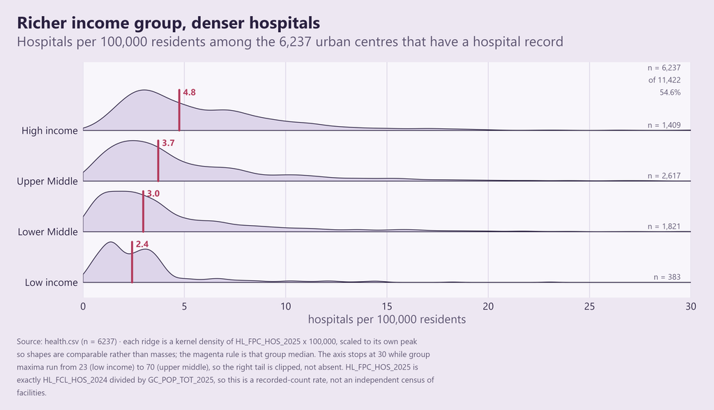

图 2: Hospital density halves from the richest to the poorest income group, and the deficit is a thinner floor, not a shorter ceiling.

**读数**：有医院记录的 6,237 个中心里，中位密度从高收入组的 4.8 家 / 10 万人降到低收入组的 2.4 家 / 10 万人，**差 2.0 倍**。差距不在天花板而在地板：高收入组 5% 分位是 1.55，低收入组是 0.52——低端被整体抬离零点，而不是高端更长。

这条梯度不能只归给「穷」：88.4% 的高收入中心有记录，低收入组只有 36.5% 被记进来，**能进这张图的低收入中心本来就是被记过的那一批**。所以图 2 的梯度是「在有记录的城市里」的条件结论，不是全球城市的事实。

表 2: 图 2 的原始数字（单位：每 10 万居民医院数；末列 = 该组里有多少中心真的进了图，是读这张图的前置条件）

| 收入组 | n（有医院记录） | 中位数 | 组内最大 | 组内城市中心总数 | 该组记录覆盖率 |
| --- | --- | --- | --- | --- | --- |
| High income | 1409 | 4.75 | 59.8 | 1593 | 88.4% |
| Upper Middle | 2617 | 3.71 | 70.1 | 4179 | 62.6% |
| Lower Middle | 1821 | 2.97 | 50.9 | 4591 | 39.7% |
| Low income | 383 | 2.42 | 23.1 | 1050 | 36.5% |

## 三、城市越大，药房越跟不上医院

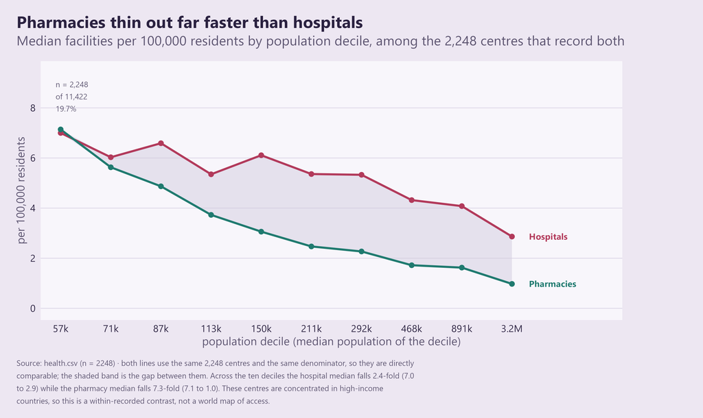

图 3: In the smallest decile pharmacies match hospitals per capita; by the largest decile hospitals outnumber them roughly three to one.

**读数**：两个序列是同一批 2,248 个中心、同一个分母，所以可以直接比。人口最小的那一档，药房中位数 7.14 家 / 10 万人**略高于**医院 7.00；到人口最大的一档反过来，医院 2.87 对药房 0.97，**约 3 比 1**。整段区间里医院只降 2.4 倍，药房降 7.3 倍。

表 3: 图 3 的原始数字（两条线同一批中心；末列 < 1 表示该档药房比医院稀）

| 人口十分位 | 组内中心数 | 人口中位数 | 医院/10万 | 药房/10万 | 药房 ÷ 医院 |
| --- | --- | --- | --- | --- | --- |
| 1 | 225 | 56,870 | 7.00 | 7.14 | 1.02 |
| 2 | 225 | 70,663 | 6.03 | 5.63 | 0.93 |
| 3 | 225 | 87,125 | 6.59 | 4.87 | 0.74 |
| 4 | 225 | 113,095 | 5.35 | 3.73 | 0.70 |
| 5 | 225 | 150,117 | 6.11 | 3.06 | 0.50 |
| 6 | 225 | 210,798 | 5.36 | 2.47 | 0.46 |
| 7 | 225 | 292,077 | 5.33 | 2.27 | 0.43 |
| 8 | 225 | 468,284 | 4.32 | 1.72 | 0.40 |
| 9 | 224 | 891,063 | 4.08 | 1.62 | 0.40 |
| 10 | 224 | 3,218,650 | 2.87 | 0.97 | 0.34 |

## 四、同城两套计数能对上吗

四个互斥类里，「两者都有记录」只占 2,248 个（19.7%），其余是 3,989 个只有医院、148 个只有药房、5,037 个两者皆无。要问「同一座城市里药房比医院多还是少」，**全库只剩 2,248 个中心能回答**。

表 4: 两者都有记录的 2,248 个中心：药房数 ÷ 医院数（< 1 = 药房少于医院；中位数在前三档正好落在 1.00）

| 人口十分位 | n | P25 | 中位数 | P75 |
| --- | --- | --- | --- | --- |
| 1 | 225 | 0.50 | 1.00 | 2.00 |
| 2 | 225 | 0.50 | 1.00 | 1.67 |
| 3 | 225 | 0.43 | 1.00 | 2.00 |
| 4 | 225 | 0.33 | 0.92 | 1.50 |
| 5 | 225 | 0.33 | 0.67 | 1.75 |
| 6 | 225 | 0.25 | 0.44 | 1.12 |
| 7 | 225 | 0.20 | 0.43 | 1.00 |
| 8 | 225 | 0.19 | 0.43 | 1.04 |
| 9 | 224 | 0.17 | 0.41 | 0.97 |
| 10 | 224 | 0.12 | 0.26 | 0.74 |

## 数据异常（记录，不改数据）

| 现象 | 原始数字 | 处理 |
| --- | --- | --- |
| 药房字段大面积缺失 | 2396 / 11,422 有值（21.0%）；三个收入组低于 22% | 不当 0 处理，也不填补；图 1 单列成「无记录」段，图 3 只用两者都有记录的子集 |
| 医院字段缺失 | 6237 / 11,422（54.6%） | 同上；图 2 的结论自带「在有记录的中心里」限定 |
| 计数低端几乎全是偶数 | ≤ 20 的计数里 2.8% 是奇数，> 20 的计数里 19.7% 是奇数（全库 5.3%） | 不改数；这是「图 2 的密度轴是记录量而非普查」的直接证据，写进正文与图 2 脚注 |
| 药房计数的偶数堆积更极端 | 全库奇数占比 2.8% | 图 3 只用中位数，不用均值 |
| `HL_FPC_*` 不是独立测量 | `HL_FPC_HOS_2025` 与 `HL_FCL_HOS_2024 ÷ GC_POP_TOT_2025` 的相对差最大 0.49% | 图 2 标题与脚注都写明它是派生率 |
| `HL_SHP_*` 同样是派生量 | `HL_SHP_HOS_2025` 与 `100 × HL_POP_HOS_2025 ÷ GC_POP_TOT_2025` 的最大绝对差 7.3e-08 | 本页不使用这两列，避免重复计量 |
| 年份标签不一致 | 计数是 `_2024`，人均是 `_2025`（同一列的派生），面积密度是 `_2024` | 正文引用时逐列写出年份后缀 |
| 收入组为空 | 9 个中心 | 不入图，只在图 1 的脚注交代 |
| 城市名重复 | 293 行重名（最多的重 4 次）；14 个中心名为空 | 不按城市名聚合；本页所有聚合按收入组或人口十分位 |

## 方法与口径

| 项 | 值 |
| --- | --- |
| 数据 | `data/health.csv`（11,422 × 17，`ID_UC_G0` 唯一） |
| 覆盖 | 191 个国家 / 9 个 UN SDG 区域；`GC_DEV_WIG_2025` 5 个取值（含空） |
| 入图样本 | raw 11422 -> plotted 11413 (9 个中心没有 World Bank 收入组) |
| 图 1 口径 | 四个互斥记录类（都有 / 只有医院 / 只有药房 / 都没有），列为 100% 堆叠；虚线是记录线，线上方是缺失而非 0 |
| 图 2 口径 | 只在 6,237 个有医院记录的中心内；横轴 = `HL_FPC_HOS_2025 × 100,000`（派生量）；每条屋脊各自归一到峰值，比形状不比质量；横轴截到 30，各组最大值 23 ~ 70 |
| 图 3 口径 | 只在 2,248 个两者都有记录的中心内；两条线同一分母；人口十分位按 `GC_POP_TOT_2025` 等分 |
| 不作为证据的列 | `HL_FDE_*`（面积密度）：各组中位面积从 12 km² 到 40 km² 差三倍以上，地理范围由城市化程度而非行政边界决定，面积密度会把「城市画得大」读成「设施少」 |
| 数字来源 | 正文所有数字来自本页 prep chunk 的同一份聚合；内联数字一律经 `sprintf` / `format` 定型，避开 knitr 对大数的科学计数法改写 |
| 不画的东西 | 不按国家排名（中国 1,974、印度 1,925 个中心，占了库的三分之一，国家间比较会被中心定义差异主导）；不画时间趋势（只有 2024 / 2025 两个年份且同名同列）；不用均值（低端偶数堆积 + 长尾会把均值推离典型值） |